# ETC5512: Data Ethics and Privacy

## Data Ethics and Privacy

When you make data open you don’t always know how people will use it. This means we need to stop and think practically:

- How are people likely to want to use this data set?
- What might people being curious about using this data?

We also need to consider aspects of data ethics and privacy:

- Are there any applications of our data that we may want to protect against?
- How can protect people’s privacy?

**NoteQuick concept check**

What methods have we seen so far for de-identifying data? *Hint: Think back to the census week! Think back to our wild caught data types in week 1.*

## Data

You can download the data for today’s class from the development version of the R package `ggdibbler`.

```r
if(!require("pak"))
  installed.packages("pak")

if(!require("ggdibbler"))
  pak::pak("harriet-mason/ggdibbler")

library(ggdibbler)
data("walktober")

# ?walktober
```

## Quick Look

```r
library(tidyverse)

glimpse(walktober)
```

```
Rows: 744
Columns: 4
$ team  <chr> "iwalk()", "iwalk()", "iwalk()", "iwalk()", "iwalk()", "iwalk()"…
$ name  <chr> "A", "A", "A", "A", "A", "A", "A", "A", "A", "A", "A", "A", "A",…
$ date  <chr> "01/10/25", "02/10/25", "03/10/25", "04/10/25", "05/10/25", "06/…
$ steps <int> 21526, 16656, 22329, 23753, 9307, 15062, 11155, 15660, 18526, 25…
```

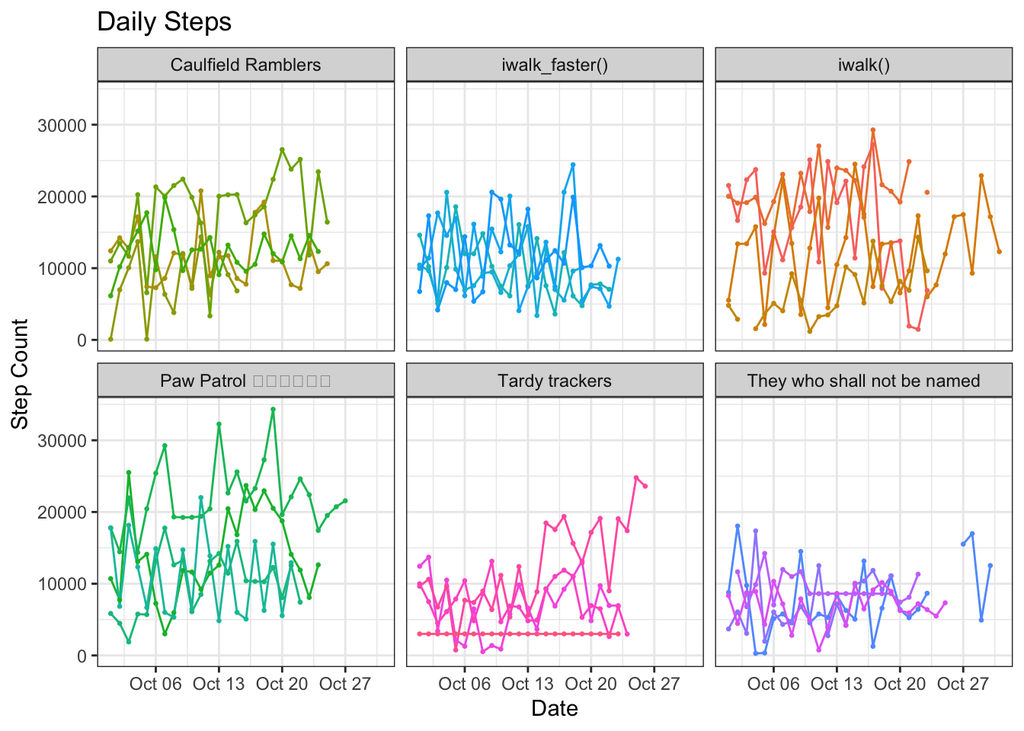

```r
walktober |>
  mutate(date = dmy(date)) |>
  ggplot(aes(x = date, y = steps, group = name, col = name)) +
  geom_line(size = 0.5) +
  geom_point(size = 0.5) +
  facet_wrap(~team) +
  theme_bw() +
  labs(title = "Daily Steps", y = "Step Count", x = "Date") +
  theme(legend.position = "none")
```

```r
# walktober |>
#   mutate(date = dmy(date)) |>
#   group_by(team, date) |>
#   summarise(daily_steps = sum(steps, na.rm = TRUE)) |>
#   ungroup() |>
#   ggplot(aes(x = date, y = daily_steps, colour = team)) +
#   geom_line() +
#   geom_point() +
#   labs(title = "Daily Steps by Team",
#     x = NULL,
#     y = "Total Steps",
#     colour = "Team"
#   ) +
#   theme_bw()
```

**Question:**

- What might you be curious about?
- What do you think others will be curious about?

*This matters as when we de-identify data, we need to balance the data utility against preserving people’s data privacy*

## Identification risks

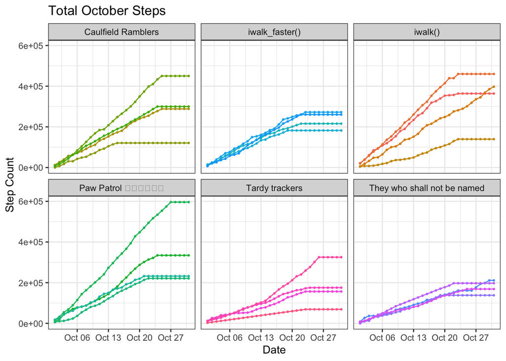

```r
walktober |>
  mutate(date = dmy(date)) |>
  group_by(team, name) |>
  arrange(date, .by_group = TRUE) |>
  mutate(total_steps = cumsum(replace_na(steps, 0))) |>
  ungroup() |>
  ggplot(aes(x = date, y = total_steps, group = name, col = name)) +
  geom_line(size = 0.5) +
  geom_point(size = 0.5) +
  facet_wrap(~team) +
  theme_bw() +
  labs(title = "Total October Steps", y = "Step Count", x = "Date") +
  theme(legend.position = "none")
```

**Question:**

- What do you think poses identification risks or re-identification risks in this data?
- Alternatively, if I told you that Kris, Maliny and I were in this data and you could ask for three additional variables to figure out who we were - what would you ask?

## Data Dictionary

**ImportantA data dictionary is different to meta data!**

Metadata tells you about a dataset; a data dictionary tells you how to interpret the contents within it.

**Data Dictionary** – A structured document/catalog that defines the details of data(e.g., variables names, data types, allowed values, and descriptions). Think of it as the “user manual” for a dataset.

**Metadata** – Data about data — high-level information describing a dataset’s context, such as who created it, when, its size, and format. Think of it as the “label on a tin can” that tells you what’s inside without opening it.

| Variable | Description | Type | Other Information |
| --- | --- | --- | --- |
| `team` | Original team name | `character string` | No fixed length, may contain emojis, has not been de-identified |
| `name` | References individual participants | `character string` | Individuals have been de-identified by replacing the names with a letter. Currently single letters only (<26 participants), but string length would increase if new participants added |
| `date` | Date of recorded step count | `character string` | Stored as character in raw data, should be converted to a date variable with AEST timezone for analysis |
| `steps` | Number of steps recorded by the participant on that date | `integer` | Sources include wearables, phone apps, and estimated workout proxies (biking, running, pilates). `NA` values occur due to non-reporting or reluctance to report small totals |